# MTH6139 Time Series

Coursework 1

Taisiya Sosina

March 2024

## 1 Introduction

This file aims to use time-series forecasting and utilizing prophet to forecast store sales on data from Corporación Favorita, a large Ecuadorian supermarket company.

### 1.1 Data Set

The data set used is available at Kaggle on the link :

https://www.kaggle.com/competitions/store-sales-time-series-forecasting

For this project I will be simplifying the data to take the total unit sales for each day, from the training data only. The training data-set includes the dates ,store number and product category and the sales numbers.

### 1.2 Meta’s Prophet forecasting system.

Meta’s Prophet forecasting system uses a decomposable time series model that follows the following formula:

$$y(t) =g(t) +s(t) +h(t) +\epsilon
(t)$$

$g(t)$ : The Trend Function

$s(t)$ : Seasonality

$h(t)$ : The Effects of Holidays

$\epsilon (t)$ : The Error Term

### 1.3 Prerequesits

You will need the following libraries to run the code described below:

```r
library(readr)   #Used to read the CSV
library(dplyr)   #Used for Data Manipulation
library(prophet) #Used in 3
library(ggplot2) #Used in 2.2
library(Metrics) #Used in 4
```

## 2 Dataset

### 2.1 Exploring the Dataset

Lets start by doing some basic commands to explore the data set.

```r
head(Train_store_sales)
```

```
## # A tibble: 6 × 6
##      id date       store_nbr family       sales onpromotion
##   <dbl> <date>         <dbl> <chr>        <dbl>       <dbl>
## 1     0 2013-01-01         1 AUTOMOTIVE       0           0
## 2     1 2013-01-01         1 BABY CARE        0           0
## 3     2 2013-01-01         1 BEAUTY           0           0
## 4     3 2013-01-01         1 BEVERAGES        0           0
## 5     4 2013-01-01         1 BOOKS            0           0
## 6     5 2013-01-01         1 BREAD/BAKERY     0           0
```

```r
summary(Train_store_sales)
```

```
##        id               date              store_nbr       family
##  Min.   :      0   Min.   :2013-01-01   Min.   : 1.0   Length:3000888
##  1st Qu.: 750222   1st Qu.:2014-02-26   1st Qu.:14.0   Class :character
##  Median :1500444   Median :2015-04-24   Median :27.5   Mode  :character
##  Mean   :1500444   Mean   :2015-04-24   Mean   :27.5
##  3rd Qu.:2250665   3rd Qu.:2016-06-19   3rd Qu.:41.0
##  Max.   :3000887   Max.   :2017-08-15   Max.   :54.0
##      sales           onpromotion
##  Min.   :     0.0   Min.   :  0.000
##  1st Qu.:     0.0   1st Qu.:  0.000
##  Median :    11.0   Median :  0.000
##  Mean   :   357.8   Mean   :  2.603
##  3rd Qu.:   195.8   3rd Qu.:  0.000
##  Max.   :124717.0   Max.   :741.000
```

### 2.2 Cleaning and Simplifying

As said earlier, we will be simplifying and getting this data ready for our analysis.

```r
#checking for missing values (there are none)
sum(is.na(Train_store_sales))
```

```
## [1] 0
```

```r
#This way we are disregarding the store number and family of sales and just counting total number of sales per day. Note you will need the dplyr library for this.
daily_sales <- Train_store_sales %>%
  group_by(date) %>%
  summarize(total_sales = sum(sales))

## converting to dataframe (this is needed for prophet)
my_df <- as.data.frame(daily_sales)
colnames(my_df) <- c("ds", "y")
head(my_df)
```

```
##           ds          y
## 1 2013-01-01   2511.619
## 2 2013-01-02 496092.418
## 3 2013-01-03 361461.231
## 4 2013-01-04 354459.677
## 5 2013-01-05 477350.121
## 6 2013-01-06 519695.401
```

Now we have everything ready to start doing analysis.

### 2.3 Exploring Dataset

Lets start off by plotting the time series

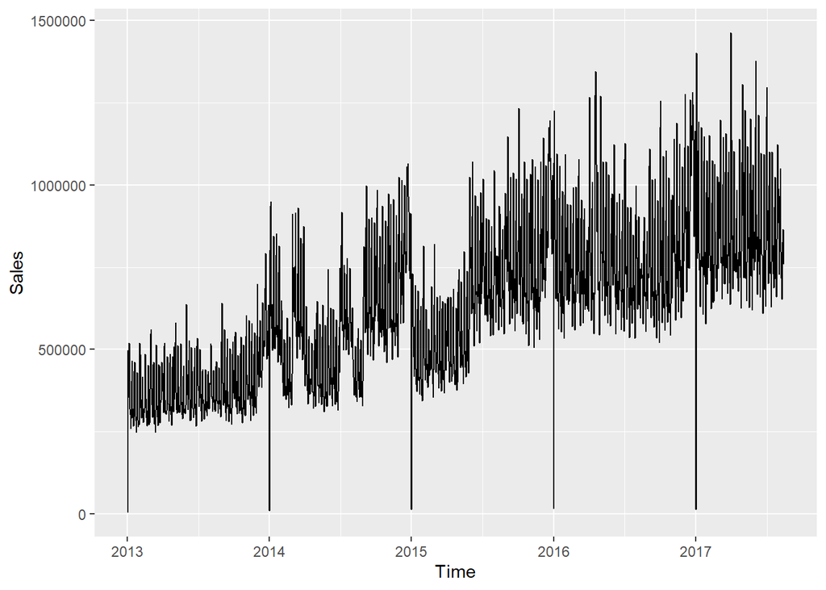

```r
ggplot(my_df, aes(x=ds, y=y)) + xlab('Time') + ylab('Sales') +
  geom_line()
```

We can also look at only the first year.

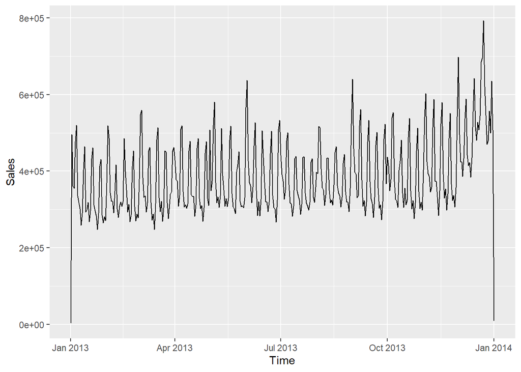

```r
my_df_short = my_df[0:365, ]
ggplot(my_df_short, aes(x=ds, y=y)) + xlab('Time') + ylab('Sales') +
  geom_line()
```

## 3 Time Seires

### 3.1 Prophet Model

Let’s finally fit out data to the model: $m$ is the fitted model. $f$ is the data frame that will holds the dates for our future prediction data. $p$ is our prediction data

```r
m = prophet::prophet(my_df)
```

```
## Disabling daily seasonality. Run prophet with daily.seasonality=TRUE to override this.
```

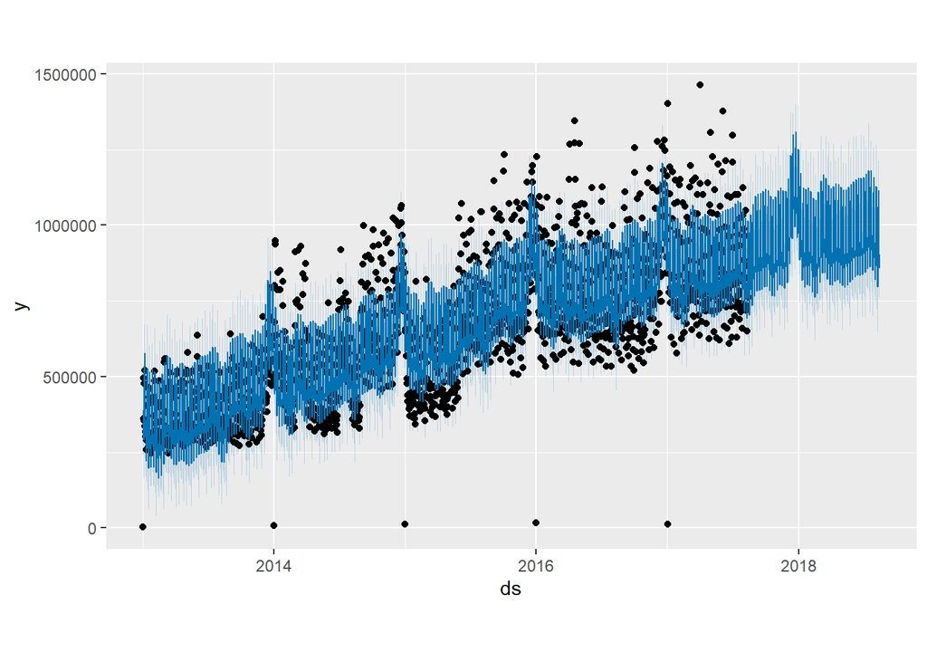

```r
## we want to make predictions for one year
f = prophet::make_future_dataframe(m, periods=365, freq="days")

p = predict(m, f)
plot(m,p)
```

We can also decompose our model into trend and seasonality. For this case we do not have daily seasonality, however prophet can do this too. We will also have a look at *Holidays* later.

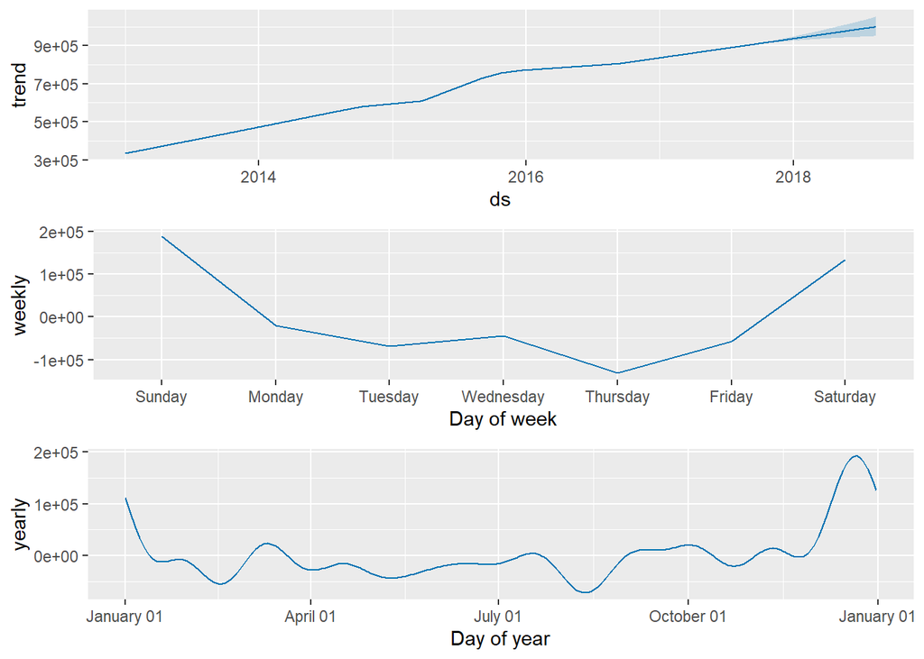

```r
prophet::prophet_plot_components(m, p)
```

#### What we can say:

- As we said early we can see by the trend that the sales is growing linearly.
- Sunday and Saturday are the highest sales days, which makes logical sense.
- It’s visible that sales go up at the end of December around Christmas.
- This model does not seem to understand that the stores are closed on the 1st of January.

### 3.2 Holiday effect

If we want to add holidays to prophet we have to add a a data frame for them that has two columns *holidays* and *ds*.

Let’s add the New year as a holiday to better plot the fact that the stores are closed on the New years and re-run our model.

```r
New_year <- data_frame(
  holiday = 'New_Year',
  ds = as.Date(c('2013-01-01', '2014-01-01', '2015-01-01','2016-01-01','2017-01-01','2018-01-01'))
)
holidays = New_year
m_holidays = prophet::prophet(holidays = holidays)
m_holidays = prophet::fit.prophet(m_holidays, my_df)
```

```
## Disabling daily seasonality. Run prophet with daily.seasonality=TRUE to override this.
```

```r
f_holidays = prophet::make_future_dataframe(m_holidays, periods=365, freq="days")
p_holidays = predict(m_holidays, f_holidays)
```

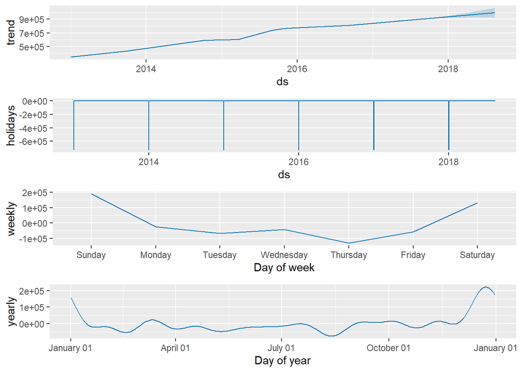

```r
prophet::prophet_plot_components(m_holidays, p_holidays)
```

We now see that we have a new component called *holidays* in our plot components. This will take away a large value from the predicted value on January first. However, it is worth noting that it still doesn’t make it 0.

## 4 Results

We can split our data set into *test* and *train* data.

```r
### Train and test
my_df_train = my_df[0:1457, ]
my_df_test = my_df[1458:1684 , ]
```

- Train is the first 4 years from 2013-01-01 to 2016-12-31.
- Test is from 2017-01-01 to 2017-08-15. There is 227 days to be predicted

We can now fit our holiday model to the train data set:

```r
m_holidays_train = prophet::prophet(holidays = holidays)
m_holidays_train = prophet::fit.prophet(m_holidays_train, my_df_train)
```

```
## Disabling daily seasonality. Run prophet with daily.seasonality=TRUE to override this.
```

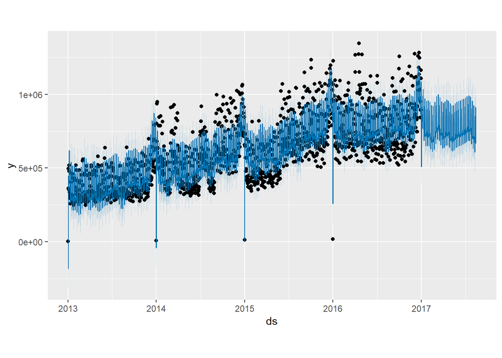

```r
f_holidays_train = prophet::make_future_dataframe(m_holidays_train, periods=227, freq="days") # Note how this is now 227 days
p_holidays_train = predict(m_holidays_train, f_holidays_train)
plot(m_holidays_train,p_holidays_train)
```

We can use the *Metric* library to find out the RMSE.

```r
preds_holiday = p_holidays_train$yhat[1458:1684]
rmse(my_df_test$y,preds_holiday)
```

```
## [1] 136060.6
```

## 5 Conclusion and Further Work

There is definitely room for improvement here. Lets have a look at the model with the testing data points.

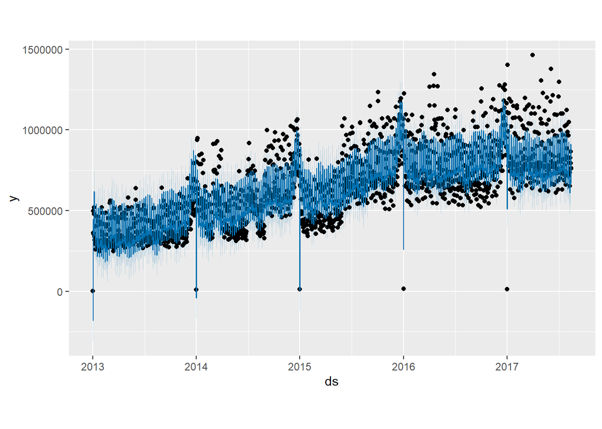

```r
plot(m_holidays,p_holidays_train)
```

#### Evaluation

1. Firstly, the trend is not well represented in 2017 and for some reason all our values seem to be under fitted. This did not seem like an issue when we had data for 2017 includedin our trianing. That being said , the trend somewhat slows down for 2016 so that could be the issue.
2. This is further backed by the very high values for RMSE that we obtained in our results
3. Even though 1st of January is lower then the 1st model (without added holidays) it is still not 0.

#### Further Improvements

- It would be great to set the predicted value for 1st of Jan as 0.
- Add other holidays of Ecuador to the holidays data frame mentioned earlier.
- Fix the trend for 2017.
- Separate the predictions by store number and family of item (category).